# Notes: Approximate Methods

So far in this course we have focused on covering the process and methods of principled inference, and putting them into practice. Hopefully, this all seems possible, at least in the context of tutorials guiding you through pre-solved problems. In real life, however, it's very easy to end up in a situation where plugging through this process to generate samples from the posterior distribution appears to be computationally impossible in a reasonable amount of time. What then?

The short answer, as far as these notes go, is: don't give up. There are a strategies that could be described as approximate methods that fit within the formalism we've been using, as we'll summarize below.

## But first... we we really *need* new methods?

Apologies for the exasperating question, but it really is worth asking. We try to keep the computing overhead for this class low enough that an old laptop can churn through any tutorial in at most a couple of minutes tops, but that's because we're just as impatient as you are. (Or more, considering that we have to run all of them that are turned in...) For real life problems, having to wait a few hours, or days, or even weeks, depending on the importance/finality of the inference might be fine. High-performace computing is obviously a great resource if you have access to it, and MCMC is famously "embarassingly parallelizable".

But let's assume that simple impatience is not the issue. The next thing to ask is whether the theoretical part of the model, whatever it is, can be justifiably approximated and its evaluation thus sped up. Cows may not be spherical, but simplifying the description of complex phenomena, what it's defensible to do so, is a big part of science.

Last, we can think of ways to make the inference algorithms we already have work faster. There's a reason we spend so much time on methods in this course instead of just introducing `pymc` and calling it a day. It's because mindless, brute-force application of any of the methods we've covered, even the fanciest, will not be efficient all the time. When efficiency really matters, applying some human intelligence can be a game changer. Since all samplers that we know of bog down when the dimensionality of the parameter space becomes large, a recommended approach is to see if the number of parameters *to be sampled* can be reduced. For example,

- by taking advantage of conjugacies (this is still sampling the parameters, but potentially much more efficiently than generic methods);
- by marginalizing over some parameters through direct (analytic or numerical) integration;
- by constraining *intermediate* posterior distributions before combining the information in them (in hierarchical problems).

Several of the "Practice"-level tutorials explore these tricks. For the rest of these notes, we'll assume that they won't cut it, and we do need to approximate.

## Approximate Bayesian Computation (ABC)

Ok, you've rolled your eyes through the previous section and determined that it really is necessary to find an alternative to traditional MCMC methods. The next contender for consideration is Approximate Bayesian Computation.

ABC is a family of sampling methods all based on the idea that if we can generate a mock dataset that is sufficiently similar to the observed data, then the parameters of that model are a plausible draw from the posterior PDF.

In this approach the likelihood function is never explicitly evaluated, and so it is sometimes described as being "likelihood-free". This terminology is misleading at best since ABC relies on a generative model; as you well appreciate, a generative model is not complete with a sampling distribution, and sampling distributions are equivalent to likelihood functions. That said, there are situations when we can generate from a sampling distribution much more easily than we can evaluate its density. This is the use case for ABC.

Suppose we have a data set $d$, and a generative model, $H$, with parameters $\theta$. The simplest ABC algorithm is as follows:

- Draw $\theta$ from the prior PDF, $p(\theta|H)$.
- Generate a mock data set, $d'$.
- Compute the "distance" between the observed and mock datasets, $\rho(d,d')$.
- If the distance $\rho(d,d') < \varepsilon$, store $\theta$ as a sample. Otherwise, reject it.
- Repeat.

Similarly, we get to choose $\varepsilon$, with the goal being to make it small enough that our approximation to the posterior is good.

You may recognize a similarity to rejection sampling (or Metropolis-Hastings) above. What ABC gives us is samples from $p(\theta | \rho[d,d'(\theta)] < \varepsilon, H)$. If $\varepsilon \rightarrow 0$, this will be exactly the true posterior, $p(\theta | d, H)$. If $\varepsilon \rightarrow \infty$, it will instead be the prior, $p(\theta|H)$. In practice, what we get is something in between, and the hope is that with a small enough $\varepsilon$ it will be close to the posterior, while still not rejecting in too many iterations.

As you might guess, this method requires some care. If the summary statistics are not close to being *sufficient statistics*$^1$ for $\theta$ (i.e. encoding all of the information the data have about $\theta$), the approximate posterior will be too broad. If we try to use too many summary statistics, it may be too difficult for mock data sets to match the real data. If $\varepsilon$ is not set correctly, sampling can be either too inefficient or not meaningful. If the distance function effectively gives much more weight to some summary statistics than others, we may find that reasonable values of $\varepsilon$ can accurately constrain some combinations of parameters, but not others.

In the end, we're left with an approximate posterior, and need to decide whether it's adequate for our purposes. Here posterior prediction and cross-validation can help.

It's worth noting again that the algorithm above is the *simplest* ABC implementation. As with MCMC, there are a number of modifications that can make it more efficient (in the sense of requiring fewer rejections), potentially allowing us to be more demanding with our choice of $\varepsilon$. In fact, the implementations listed below use a version of population monte carlo, adaptively updating the distribution sampled from and reducing $\varepsilon$ to gradually approach the true posterior.

### Packages implementing ABC

- [pyABC](https://pyabc.readthedocs.io/en/latest/index.html)
- [ABCpy](https://abcpy.readthedocs.io/en/latest/index.html)

### Aside: dimensionality reduction

The use of a set of summary statistics in place of a larger data set in ABC is an example of "dimensionality reduction", a generally effective and practical way to avoid computational overheads. Whether under that name or not, and whether within the context of ABC or not (usually not), this approach is ubiquitous. In general, the idea is to reduce (literally) the data by compressing it into a form that can be modeled with a much smaller number of parameters.

Any time we truncate a generative model before it goes all the way to the rawest form of recorded data, we are in principle engaging in dimensionality reduction. Usually this is well justified, particularly if the sampling distribution for the reduced model is well understood. However, it's worth questioning whether simple dimensionality reduction, as opposed to ABC, is a good idea when the sampling distribution of the reduced model is something we can only guess at (including arguing for the central limit theorem and/or doing simulations).

## The Laplace approximation

Suppose that the sampling distribution is calculable, but so expensive that we are *highly* motivated to minimize the number of times we need to do so. (And suppose that ABC is also prohibitive, for some reason.)

As a last resort, we can hope that the central limit theorem makes our posterior distribution approximately Gaussian. We presumably cannot find its mean and covariance algebraically, but finding them numerically would at least involve a limited number of evaluations compared with exploring a more complex PDF. In particular, a Gaussian has a single peak, so numerical optimization (e.g. by gradient descent) might well take us there.

(There is something of a leap of faith here since optimization of a general function is neither more robust nor less expensive than sampling. Hence, much rests on us being able to find the actual posterior mode, and not some local maximum, relatively quickly.)

Once the putative posterior mode, $\hat{\theta}$, has been found, we can approximate it as Gaussian (equivalently, the log-posterior as quadratic) by Taylor expanding around the mode:

$\ln p(\theta|d) \approx \ln p(\hat{\theta}|d) + \frac{1}{2} \frac{\partial^2 \ln p}{\partial \theta^2} \bigg\rvert_{\theta=\hat{\theta}} (\theta - \hat{\theta})^2 + O[(\theta - \hat{\theta})^3]$.

Ignoring the higher order terms and exponentiating,

$p(\theta|d) \approx p(\hat{\theta}|d) \exp \left[ -\frac{1}{2} (\theta - \hat{\theta})^T H (\theta - \hat{\theta}) \right]$,

where $H$ is the "Hessian" matrix of second derivatives,

$H_{ij} = -\frac{\partial^2 \ln p}{\partial \theta_i \partial \theta_j} \bigg\rvert_{\theta=\hat{\theta}}$.

This is a multivariate Gaussian, with covariance matrix $H^{-1}$. Note that optimizers that use or numerically compute second derivatives will generally return $H^{-1}$ evaluated at the optimum for you; since numerical optimizers are traditionally *minimizers*, the minus sign we included in the definition of $H$ above would be there naturally (i.e. we would have found the minimum of $-\ln p$).

## Resampling methods

The methods in this section were invented within the frequentist framework. We'll first introduce them in that context, and then consider how they might fit into our usual inference approach.

Resampling methods try to compensate for "small sample" effects in the data, or otherwise *not knowing the sampling distribution.* The classic application for resampling is robustifying the estimation of a sample mean, when the sampling distribution appears to have heavy, non-Gaussian tails. But, in general, there is some quantity that we would like to infer from the data - we don't have a proper model to fit, but the hope is that we can somehow estimate it from the data more directly.

### Jackknife

The jackknife procedure is

1. Remove 1 (or more) data points from the data set.
2. Calculate the estimate of interest using the reduced data set.
3. Repeat this for every possible reduced data set.

The average (compared to the full-data-set calculation) and scatter of these estimates provides some idea of the small-sample bias and its scatter. In essence, we make the data set *even smaller* and see how that changes the result.

### Bootstrap

The bootstrap is a little more sophisticated. The idea is that we have data that sample a distribution (what we normally aptly call the sampling distribution), so they can be used as a direct, if crude, estimate of that distribution without further assumptions. A key requirement is that the measured data are a fair representation of draws from that distribution. The procedure is

1. Generate a new data set of the same size as the real data by sampling *with replacement* from the real data points.
2. Calculate whatever statistic or estimate is of interest from the bootstrap data set.
3. Do this many times.

Functionally, the procedure above approximates the sampling distribution as a sum of delta functions and attempts to marginalize over it. The resulting distribution is interpreted as being indicative of the true uncertainty from the sampling distribution, translated to the estimand.

### Interpretation

As promised, both of these methods are explicitly frequentist - they aim to estimate something (bias and/or variance) about an estimate!

Still, they do have an interpretation within the Bayesian framework. Specifically, both methods suggest a particular way to marginalize over uncertainty in the sampling distribution itself. This is not an issue we have come across yet, since step one of our approach has been to specify a generative model, including a sampling distribution. In fact, our usual advice when faced with uncertainty about the nature of sampling distribution itself is still to model it, possibly in multiple ways and applying model selection if necessary. On those occasions when the data set is so small that such an approach doesn't seem likely to be fruitful, and if we are ultimately interested in a simple function of the data (like an estimator), resampling methods are a plausible alternative.

## Example

Let's see how these methods work in a simple example that you will remember from the Bayes' Law notes. Namely, we are measuring a Poisson signal in our detector and want to infer the mean that gave rise to it. We previously adopted a uniform, improper prior on the mean, $\mu$, and considered the case where we measured $N=5$ counts. In PGM form, we had

- $\mu \sim \mathrm{Uniform}(0,\infty)$;
- $N \sim \mathrm{Poisson}(\mu)$.

### ABC

As described above, our task here would be to draw many samples from the prior, generate mock data for each of them, and consider those samples whose mock data are "close enough" to the real data to be approximate samples from the PDF. Immediately, we run into the problem that we cannot draw from an improper prior. In the Bayes' Law notes, we ended up taking $\mu\sim\mathrm{Uniform}(0,10^{10})$ so that the prior would be proper for numerical purposes, but this is still impractical for our purposes - we cannot reasonably expect any mock data to be close to the real data when drawing from such a wide distribution. In short, we have created a problem by adopting a ridiculous prior instead of thinking about what would be justified. As in the case of parameter estimation by MCMC, however, we really only need the prior to be wide enough that the posterior (which will be proper in this case) becomes negligibly small within it. As this is a contrived example, we will forgo arguing for a contrived informative prior, and adopt $\mu\sim\mathrm{Uniform}(0,50)$; we can always check that the posterior is contained in this range in the end.

With that settled, what might be "close enough" when comparing the real and mock data in this case? The ideal would be to require them to be exactly equal, which we can get away with in this case. In general, one would need to decide *how* to measure distance between the real and mock data first, get an idea of what order of magnitude the distances will have as we draw from the prior, and then check for convergence as the threshold for closeness is lowered.

Without further ado, below we sample from the prior, produce mock data, and then compare the approximate posterior when "close enough" means "equal" to the analytic solution from the Bayes' Law notes.

```python
import matplotlib.pyplot as plt
plt.rc('text', usetex=True)
plt.rcParams['xtick.labelsize'] = 'x-large'
plt.rcParams['ytick.labelsize'] = 'x-large'
import numpy as np
import scipy.stats as st
%matplotlib inline
```

```python
N_true = 5 # our real data

mu = st.uniform.rvs(0.0, 50.0, size=1000000) # draw from the prior
N_mock = st.poisson.rvs(mu) # generate mock data for each draw
close = (N_mock == N_true) # indices of samples we will use for the approximate posterior
```

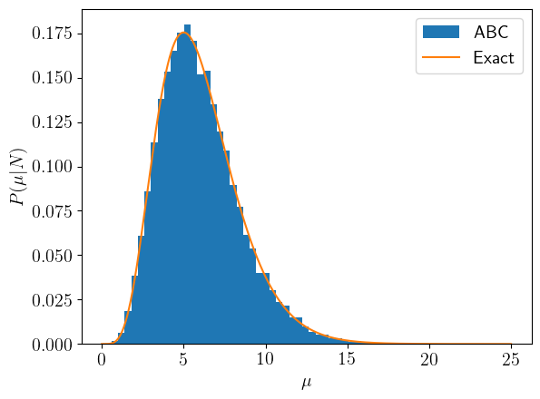

```python
mu_grid = np.linspace(0.0, 25.0, 1000)

plt.hist(mu[close], bins=50, density=True, label='ABC');
plt.plot(mu_grid, st.gamma.pdf(mu_grid, 1.0+N_true, scale=1.0), '-', label='Exact');
plt.xlabel(r'$\mu$', fontsize='x-large');
plt.ylabel(r'$P(\mu|N)$', fontsize='x-large');
plt.legend(fontsize='x-large');
```

Not bad! In fact, since we are requiring equality between the true and mock data, these samples should be exactly from the true posterior, not approximately. In situations where we would actually use ABC, we will of course not be able to get away with this. So let's see how the approximation holds up if we include samples whose mock data are within $\pm1$ of the true data.

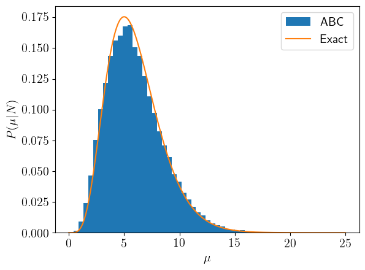

```python
close_ish = (np.abs(N_mock - N_true) <= 1)

plt.hist(mu[close_ish], bins=50, density=True, label='ABC');
plt.plot(mu_grid, st.gamma.pdf(mu_grid, 1.0+N_true, scale=1.0), '-', label='Exact');
plt.xlabel(r'$\mu$', fontsize='x-large');
plt.ylabel(r'$P(\mu|N)$', fontsize='x-large');
plt.legend(fontsize='x-large');
```

We can see that the shape of the posterior is now a bit different (heavier tailed), but not too far away. Let's go a little farther.

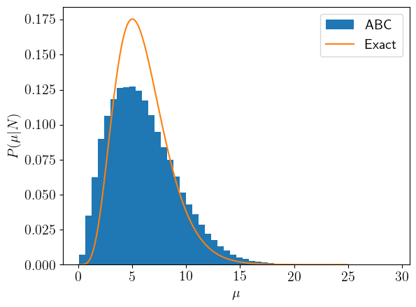

```python
close_ish = (np.abs(N_mock - N_true) <= 3)

plt.hist(mu[close_ish], bins=50, density=True, label='ABC');
plt.plot(mu_grid, st.gamma.pdf(mu_grid, 1.0+N_true, scale=1.0), '-', label='Exact');
plt.xlabel(r'$\mu$', fontsize='x-large');
plt.ylabel(r'$P(\mu|N)$', fontsize='x-large');
plt.legend(fontsize='x-large');
```

Now things are looking quite different. In practice, we wouldn't have access to an exact solution, so we would need to go in the reverse order, making the definition of "close enough" more stringent and ideally seeing the remaining samples converge to a stable PDF. Adaptive ABC schemes work this way, while simultaneously attempting to minimize the number of samples needed to approximate the posterior PDF well.

### Laplace Approximation

For this approximation, we will need to know the posterior mode and the second derivative of the log-posterior at the mode. In general, we would need to estimate these numerically, but for this problem we know that the exact solution (used above; see the Bayes' Law notes) is

$p(\mu|N) = \mathrm{Gamma}(\mu|1+N, 1) \propto \mu^N e^{-\mu}$.

With our data of $N=5$, this PDF has a mode of 5 and the Hessian evaluated at the mode is $H=1/5$ (exercise for the reader!). The Laplace Approximation thus describes the posterior as a Gaussian with mean 5 and standard deviation $\sqrt(5)$. This is compared with the exact solution below.

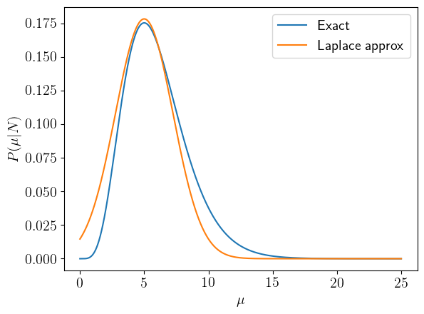

```python
plt.plot(mu_grid, st.gamma.pdf(mu_grid, 1.0+N_true, scale=1.0), '-', label='Exact');
plt.plot(mu_grid, st.norm.pdf(mu_grid, 5, np.sqrt(5)), '-', label='Laplace approx');
plt.xlabel(r'$\mu$', fontsize='x-large');
plt.ylabel(r'$P(\mu|N)$', fontsize='x-large');
plt.legend(fontsize='x-large');
```

As one would expect for what is, at heart, a Taylor expansion, the Laplace approximation is most accurate near the mode, and departs from the truth (significantly, in this case) in the tails of the PDF.

### Resampling

Finally, we'll go through the exercise of using resampling. In this example, resampling would only make sense in the case of repeated measurements, so we'll consider the set of 10 measurements from the Bayes' Law notes that came from a true mean of $\mu=5.5$.

```python
data_Ns = np.array([5, 3, 6, 5, 5, 9, 6, 8, 5, 2])
```

Recall that the resampling methods are intended to quantify the bias and uncertainty in an estimator computed from the data due to the finite sample size. In this case, it would make sense for the estimator to be the mean of the data.

```python
data_Ns.mean()
```

```
np.float64(5.4)
```

This is a small data set, so we can straightforwardly jackknife it by considering all the data sets with one entry removed, and computing the mean for each of those.

```python
ind = np.arange(len(data_Ns))
jackknives = np.array([data_Ns[ind != i].mean() for i in ind])
jackknives
```

```
array([5.44444444, 5.66666667, 5.33333333, 5.44444444, 5.44444444,
       5.        , 5.33333333, 5.11111111, 5.44444444, 5.77777778])
```

We would take the mean of those jackknife estimates to the mean of the full data set as indicative of the bias in the estimator due to the small sample size, and similarly interpret the standard deviation as indicative of the uncertainty due to the sample size.

```python
print('Jackknife bias estimate:', jackknives.mean()-data_Ns.mean())
print('Jackknife uncertainty estimate:', jackknives.std())
```

```
Jackknife bias estimate: -8.881784197001252e-16
Jackknife uncertainty estimate: 0.21773242158072706
```

For the bootstrap, we would resample the data many times with replacement, computing the mean each time. Below, we do generate 1000 bootstraps. (If the data set were a bit smaller, we might simply do the calculation for each possible resampling, but in most cases the data are large enough that we would randomly resample, as below.)

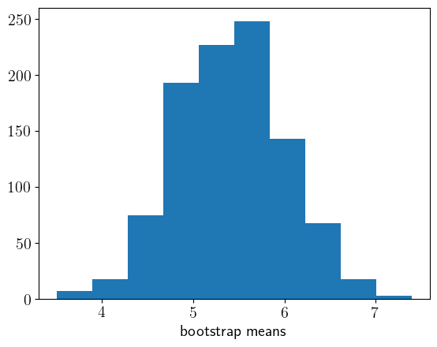

```python
boot = np.array([np.random.choice(data_Ns, size=len(data_Ns), replace=True).mean() for i in range(1000)])
plt.hist(boot);
plt.xlabel('bootstrap means', fontsize='x-large');
```

Similarly to the jackknife, we would look at the bias in the jakcknife estimates compared with the mean of the original data set, and their standard deviation. In this case, they are interpreted as being not just due to the small sample size, but to uncertainty about the underlying PDF.

```python
print('Bootstrap bias estimate:', boot.mean()-data_Ns.mean())
print('Bootstrap uncertainty estimate:', boot.std())
```

```
Bootstrap bias estimate: 0.007600000000000051
Bootstrap uncertainty estimate: 0.6221111154769701
```

Keep in mind that neither of these methods are answering the question that Bayes' Law addresses, namely what posterior PDF describes our knowledge of $\mu$ given a prior distribution and the measured data. Neither of those questions actually comes up in the simple Bayesian analysis we've been using for this example: the small size of the data set is accounted for automatically, while the posterior is conditioned on the assumption that sampling distribution is Poisson. If we weren't sure about form of the sampling distribution, within the Bayesian framework, we could marginalize over it using a mixture model (covered in the More Modeling notes).

In any case, if we *were* tempted to conflate the mean and standard deviation of the resampling estimators with the results of our usual Bayesian analysis, it's interesting to note that both of the resampling methods would underestimate the posterior uncertainty in $\mu$. The analytic posterior for this case (another exercise for the reader!) has

- mode $=5.4$, identical to the mean estimator computed on the full data set and in agreement with both resampling methods;
- mean $=5.5$, the value actually used to produce the exercise data; and
- standard deviation $=0.74$, a bit larger than either of the resampling uncertainty estimates.

#### Endnotes

##### Note 1

Sufficiency is a big deal in frequentist analysis, since the goal is to find estimators (i.e. statistics computed from the data) that work well, and taking advantage of all the information present in the data is reasonably an aspect of "working well". Frequentist estimators for a given problem (or problems similar to it) are therefore a good place to start looking for summary statistics. For example, the standard estimators for the intercept and slope might be useful summaries for a linear model, even if the assumptions underlying them do not actually hold in a given problem.